# Water Quality Results — Hawaiʻi Kona Low, March 2026

Summary of chemistry results across all sampled sites

Author

Silbiger, N., Kealoha, A., & Kahanamoku, S.

Published

July 31, 2026

# Introduction

This report summarizes water chemistry results from the *What’s In Your Water?* community science project, which collected ocean water samples across Oʻahu and Maui Nui following the March 2026 Kona Low storm. Samples were gathered by volunteer community members and scientists, and are being analyzed for salinity, nutrients (nitrate+nitrite, phosphate, silicate, and ammonium), and dissolved organic matter — key indicators of coral reef health.

Reef health thresholds for Hawaiian nearshore waters used throughout this report: NO₃+NO₂ > 1 µmol/L, PO₄ > 0.1 µmol/L, SiO₂ > 5 µmol/L, NH₃ > 1 µmol/L.

```r
library(tidyverse)
library(lubridate)
library(ggforce)
library(ggridges)
library(patchwork)
library(ggrepel)
library(ggh4x)
library(scales)
```

```r
source("01_load_clean_data.R")

cesspool_dist       <- read_csv("data/sample_cesspool_distances.csv", show_col_types = FALSE)
cesspool_by_ahupuaa <- read_csv("data/cesspool_by_ahupuaa.csv",       show_col_types = FALSE)

chem_data <- read_csv("data/ChemData.csv", show_col_types = FALSE) |>
  rename(
    sample_id = sample_ID,
    NO3NO2    = `NO3+NO2 (umol/L)`,
    PO4       = `PO4 (umol/L)`,
    SiO2      = `SiO2 (umol/L)`,
    NH3       = `NH3 (umol/L)`
  ) |>
  mutate(
    sample_id = toupper(sample_id),
    across(c(Salinity, NO3NO2, PO4, SiO2, NH3),
           ~if (is.character(.)) readr::parse_number(.) else .)
  )

df_report <- df_clean |>
  mutate(
    hour        = hour(collected_hst),
    minute      = minute(collected_hst),
    time_of_day = if_else(
      (hour * 60 + minute) >= (6 * 60) & (hour * 60 + minute) < (18 * 60 + 45),
      "Daytime", "Nighttime"
    ),
    date = as.Date(collected_hst, tz = "Pacific/Honolulu")
  ) |>
  full_join(chem_data, by = "sample_id") |>
  left_join(cesspool_dist, by = "sample_id")
```

```r
thresholds    <- c(NO3NO2 = 1, PO4 = 0.1, SiO2 = 5, NH3 = 1)
island_palette <- c("#1565C0", "#2E7D32", "#E65100", "#6A1B9A")

normalize_island <- function(x) {
  x |>
    stringr::str_replace_all("[\u02BB\u2018\u2019']", "") |>
    stringr::str_replace_all("\u0101", "a") |>
    stringr::str_to_lower() |>
    stringr::str_trim()
}
```

```r
# Exclude open-ocean samples and a known extreme outlier (M226, Kaluakoʻi)
df_chem <- df_report |>
  filter(
    ahupuaa != "Open Ocean" | is.na(ahupuaa),
    sample_id != "M226"
  )

islands       <- sort(unique(na.omit(df_chem$island)))
island_colors <- setNames(island_palette[seq_along(islands)], islands)
```

# Reef health report card

Percentage of water samples exceeding reef health thresholds for Hawaiian nearshore waters.

```r
make_gauge <- function(pct, nutrient_name, threshold_label, units = "\u00b5mol/L") {
  grade_color <- case_when(
    pct < 25 ~ "#43A047",
    pct < 50 ~ "#FB8C00",
    TRUE     ~ "#E53935"
  )
  fill_end <- (pct / 100) * pi

  ggplot() +
    geom_arc_bar(
      data = tibble(x0 = 0, y0 = 0, r0 = 0.58, r = 1, start = 0, end = pi),
      aes(x0 = x0, y0 = y0, r0 = r0, r = r, start = start, end = end),
      fill = "grey88", color = NA
    ) +
    geom_arc_bar(
      data = tibble(x0 = 0, y0 = 0, r0 = 0.58, r = 1, start = 0, end = fill_end),
      aes(x0 = x0, y0 = y0, r0 = r0, r = r, start = start, end = end),
      fill = grade_color, color = NA
    ) +
    annotate("segment",
             x = 0, xend = 0, y = 0.58, yend = 1.08,
             color = "white", linewidth = 0.8) +
    annotate("text", x = 0, y = 0.22,
             label = paste0(round(pct), "%"),
             size = 9, fontface = "bold", color = grade_color, hjust = 0.5) +
    annotate("text", x =  1.2, y = -0.02, label = "0%",
             size = 3, color = "grey55", hjust = 0.5) +
    annotate("text", x = -1.2, y = -0.02, label = "100%",
             size = 3, color = "grey55", hjust = 0.5) +
    coord_cartesian(xlim = c(-1.6, 1.6), ylim = c(-0.45, 1.25)) +
    ggtitle(
      nutrient_name,
      subtitle = paste0("threshold: >", threshold_label, " ", units)
    ) +
    theme_void() +
    theme(
      aspect.ratio  = 1.7 / 3.2,
      plot.title    = element_text(hjust = 0.5, face = "bold", size = 13,
                                   color = "grey15", margin = margin(b = 1)),
      plot.subtitle = element_text(hjust = 0.5, size = 9,
                                   color = "grey55", margin = margin(b = 2)),
      plot.margin   = margin(8, 8, 8, 8)
    )
}
```

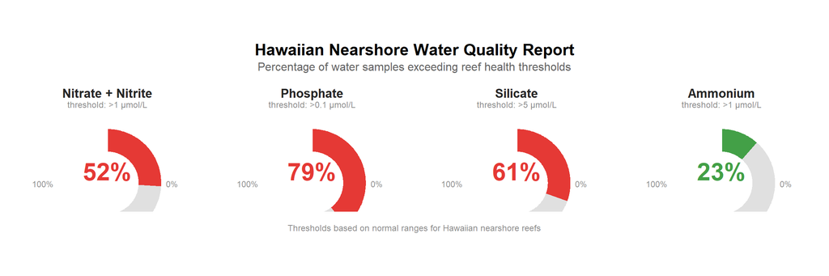

```r
exceed_pcts <- df_chem |>
  select(NO3NO2, PO4, SiO2, NH3) |>
  summarise(across(
    everything(),
    ~round(mean(. > thresholds[cur_column()], na.rm = TRUE) * 100)
  )) |>
  unlist()

(make_gauge(exceed_pcts["NO3NO2"], "Nitrate + Nitrite", 1)  +
 make_gauge(exceed_pcts["PO4"],    "Phosphate",         0.1) +
 make_gauge(exceed_pcts["SiO2"],   "Silicate",          5)   +
 make_gauge(exceed_pcts["NH3"],    "Ammonium",          1)) +
  plot_layout(ncol = 4, nrow = 1) +
  plot_annotation(
    title    = "Hawaiian Nearshore Water Quality Report",
    subtitle = "Percentage of water samples exceeding reef health thresholds",
    caption  = "Thresholds based on normal ranges for Hawaiian nearshore reefs",
    theme    = theme(
      plot.title    = element_text(face = "bold", size = 17, hjust = 0.5,
                                   margin = margin(b = 4)),
      plot.subtitle = element_text(size = 12, hjust = 0.5, color = "grey40",
                                   margin = margin(b = 8)),
      plot.caption  = element_text(size = 9, color = "grey55", hjust = 0.5)
    )
  )
```

**TipInterpretation**

# Nutrient concentrations — all samples

Each dot is one water sample. The dashed red line marks the reef health threshold. Dots to the right of the line exceeded the threshold.

```r
make_one_strip <- function(df_col, display_label, thresh) {
  if (nrow(df_col) == 0) return(ggplot() + theme_void())
  ggplot(df_col, aes(x = value, y = island, color = island)) +
    geom_jitter(height = 0.2, width = 0, alpha = 0.55, size = 1.8) +
    geom_vline(xintercept = thresh, color = "firebrick",
               linetype = "dashed", linewidth = 0.8) +
    scale_color_manual(values = island_colors, guide = "none") +
    scale_x_continuous(trans  = "log1p",
                       labels = label_number(drop0trailing = TRUE)) +
    labs(title = display_label, x = NULL, y = NULL) +
    theme_minimal(base_size = 12) +
    theme(
      panel.grid.major.y = element_blank(),
      panel.grid.minor   = element_blank(),
      plot.title         = element_text(face = "bold", size = 11)
    )
}
```

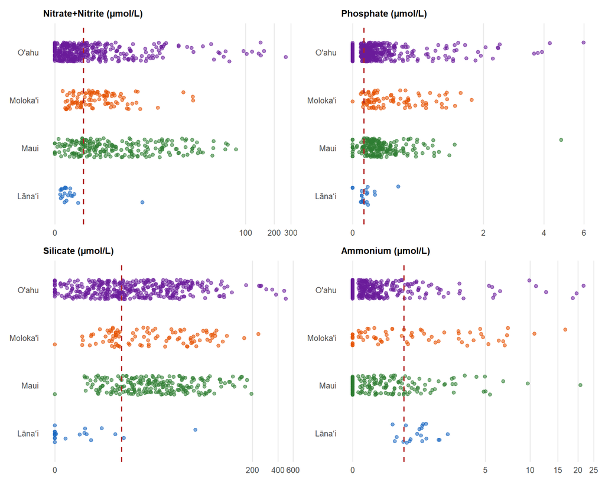

```r
strip_df <- df_chem |>
  filter(!is.na(island)) |>
  select(sample_id, island, NO3NO2, PO4, SiO2, NH3) |>
  mutate(island = factor(island, levels = sort(unique(island))))

p_no3  <- make_one_strip(strip_df |> filter(!is.na(NO3NO2)) |> mutate(value = NO3NO2),
                         "Nitrate+Nitrite (\u00b5mol/L)", 1)
p_po4  <- make_one_strip(strip_df |> filter(!is.na(PO4))   |> mutate(value = PO4),
                         "Phosphate (\u00b5mol/L)", 0.1)
p_sio2 <- make_one_strip(strip_df |> filter(!is.na(SiO2))  |> mutate(value = SiO2),
                         "Silicate (\u00b5mol/L)", 5)
p_nh3  <- make_one_strip(strip_df |> filter(!is.na(NH3))   |> mutate(value = NH3),
                         "Ammonium (\u00b5mol/L)", 1)

(p_no3 + p_po4) / (p_sio2 + p_nh3)
```

**TipInterpretation**

# Salinity distribution by island

Each curve shows the full spread of salinity readings across samples from that island. The dotted green lines mark normal seawater (34–36 psu) — values to the left indicate freshwater mixing from storm runoff.

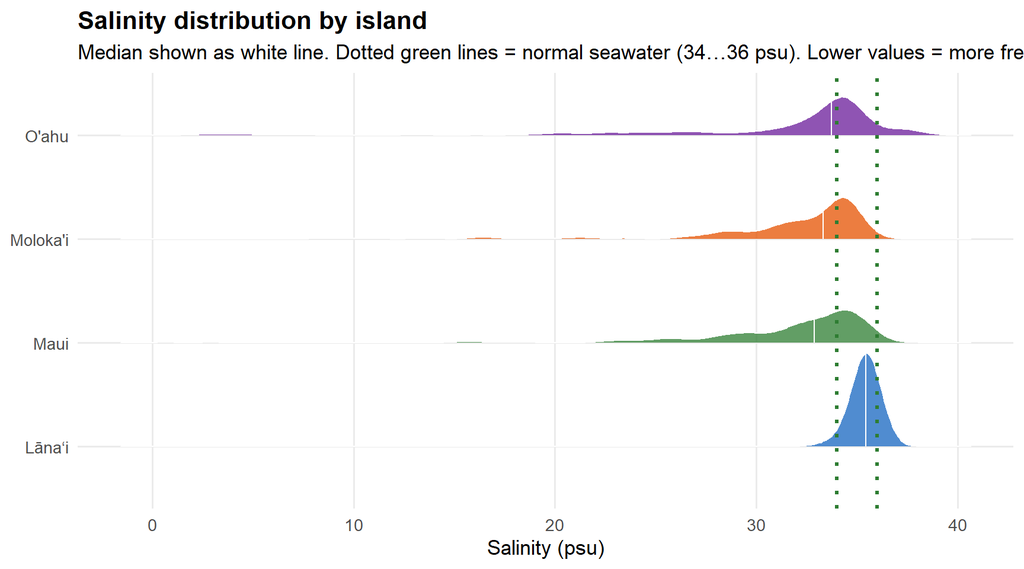

```r
sal_df <- df_chem |> filter(!is.na(Salinity), !is.na(island))

ggplot(sal_df, aes(x = Salinity, y = island, fill = island)) +
  geom_density_ridges(
    alpha          = 0.75,
    scale          = 0.9,
    quantile_lines = TRUE,
    quantiles      = 2,
    color          = "white"
  ) +
  geom_vline(xintercept = 34, color = "#2E7D32", linetype = "dotted", linewidth = 1.1) +
  geom_vline(xintercept = 36, color = "#2E7D32", linetype = "dotted", linewidth = 1.1) +
  scale_fill_manual(values = island_colors, guide = "none") +
  labs(
    title    = "Salinity distribution by island",
    subtitle = "Median shown as white line. Dotted green lines = normal seawater (34\u202636\u00a0psu). Lower values = more freshwater.",
    x        = "Salinity (psu)",
    y        = NULL
  ) +
  theme_minimal(base_size = 13) +
  theme(
    panel.grid.minor = element_blank(),
    plot.title       = element_text(face = "bold")
  )
```

**TipInterpretation**

Maui shows the most pronounced freshwater mixing, with a large portion of samples falling well below 34 psu — indicating strong land-ocean connectivity during the storm. Oʻahu and Molokaʻi also show clear freshwater pulses, while Lānaʻi samples remained close to normal salinity. Low salinity is often the first warning signal that storm runoff has reached a reef.

# Pollution burden by island

Share of analyzed samples by how many nutrient thresholds were simultaneously exceeded. Darker colors indicate more nutrients above threshold at the same site.

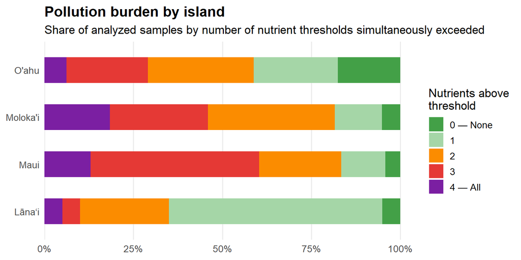

```r
burden_df <- df_chem |>
  filter(!is.na(island)) |>
  filter(!is.na(NO3NO2) | !is.na(PO4) | !is.na(SiO2) | !is.na(NH3)) |>
  mutate(
    n_exceeded =
      (!is.na(NO3NO2) & NO3NO2 > thresholds["NO3NO2"]) +
      (!is.na(PO4)    & PO4    > thresholds["PO4"])    +
      (!is.na(SiO2)   & SiO2   > thresholds["SiO2"])   +
      (!is.na(NH3)    & NH3    > thresholds["NH3"]),
    n_exceeded = factor(
      n_exceeded,
      levels = 0:4,
      labels = c("0 \u2014 None", "1", "2", "3", "4 \u2014 All")
    )
  ) |>
  count(island, n_exceeded) |>
  group_by(island) |>
  mutate(prop = n / sum(n)) |>
  ungroup()

ggplot(burden_df, aes(x = prop, y = island, fill = n_exceeded)) +
  geom_col(position = "stack", width = 0.55) +
  scale_fill_manual(
    values = c(
      "0 \u2014 None" = "#43A047",
      "1"            = "#A5D6A7",
      "2"            = "#FB8C00",
      "3"            = "#E53935",
      "4 \u2014 All"  = "#7B1FA2"
    ),
    name = "Nutrients above\nthreshold"
  ) +
  scale_x_continuous(
    labels = percent,
    expand = expansion(mult = c(0, 0.03))
  ) +
  labs(
    title    = "Pollution burden by island",
    subtitle = "Share of analyzed samples by number of nutrient thresholds simultaneously exceeded",
    x        = NULL,
    y        = NULL
  ) +
  theme_minimal(base_size = 13) +
  theme(
    panel.grid.major.y = element_blank(),
    panel.grid.minor   = element_blank(),
    plot.title         = element_text(face = "bold"),
    legend.position    = "right"
  )
```

**TipInterpretation**

# Water quality stoplight by moku

Percentage of samples exceeding reef health thresholds for each nutrient, grouped by traditional Hawaiian land division (moku). Moku with fewer than 3 analyzed samples are excluded.

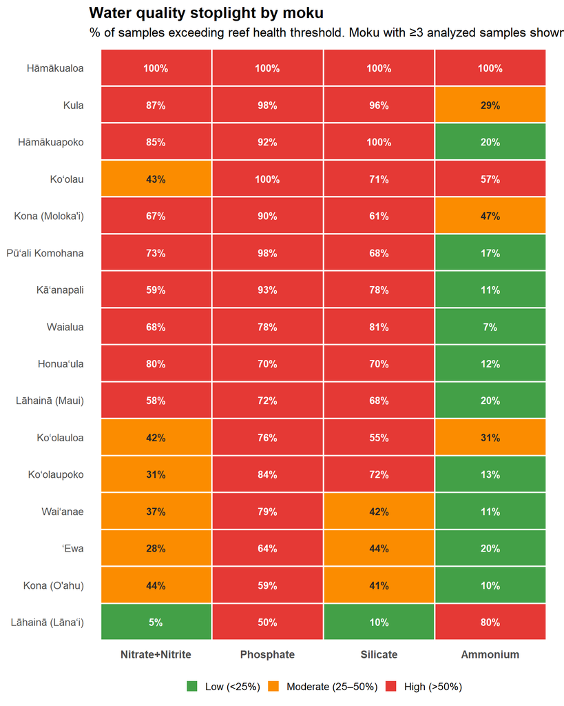

```r
heatmap_df <- df_chem |>
  filter(!is.na(moku)) |>
  group_by(island, moku) |>
  summarise(
    n                 = n(),
    `Nitrate+Nitrite` = mean(NO3NO2 > thresholds["NO3NO2"], na.rm = TRUE) * 100,
    `Phosphate`       = mean(PO4    > thresholds["PO4"],    na.rm = TRUE) * 100,
    `Silicate`        = mean(SiO2   > thresholds["SiO2"],   na.rm = TRUE) * 100,
    `Ammonium`        = mean(NH3    > thresholds["NH3"],     na.rm = TRUE) * 100,
    .groups = "drop"
  ) |>
  filter(n >= 3) |>
  pivot_longer(
    c(`Nitrate+Nitrite`, Phosphate, Silicate, Ammonium),
    names_to = "nutrient", values_to = "pct"
  ) |>
  filter(!is.nan(pct)) |>
  mutate(
    label = if_else(
      moku %in% c("L\u0101hain\u0101", "Kona"),
      paste0(moku, " (", island, ")"),
      moku
    ),
    label    = fct_reorder(label, pct, mean, .na_rm = TRUE),
    nutrient = factor(nutrient,
                      levels = c("Nitrate+Nitrite", "Phosphate", "Silicate", "Ammonium")),
    grade = case_when(
      pct < 25 ~ "Low",
      pct < 50 ~ "Moderate",
      TRUE     ~ "High"
    ),
    grade = factor(grade, levels = c("Low", "Moderate", "High"))
  )

ggplot(heatmap_df, aes(x = nutrient, y = label, fill = grade)) +
  geom_tile(color = "white", linewidth = 0.8) +
  geom_text(
    aes(label = paste0(round(pct), "%"),
        color = grade == "Moderate"),
    size = 3.5, fontface = "bold"
  ) +
  scale_fill_manual(
    values = c("Low" = "#43A047", "Moderate" = "#FB8C00", "High" = "#E53935"),
    name   = NULL,
    labels = c("Low (<25%)", "Moderate (25\u201350%)", "High (>50%)")
  ) +
  scale_color_manual(
    values = c("TRUE" = "grey15", "FALSE" = "white"),
    guide  = "none"
  ) +
  labs(
    title    = "Water quality stoplight by moku",
    subtitle = "% of samples exceeding reef health threshold. Moku with \u22653 analyzed samples shown.",
    x = NULL, y = NULL
  ) +
  theme_minimal(base_size = 13) +
  theme(
    panel.grid      = element_blank(),
    plot.title      = element_text(face = "bold"),
    axis.text.x     = element_text(face = "bold", size = 11),
    legend.position = "bottom",
    legend.key.size = unit(1, "lines")
  )
```

**TipInterpretation**

Several moku show high (≥50%) exceedance rates across multiple nutrients simultaneously, pointing to areas with compounding pollution pressure. Phosphate and silicate tend to show the broadest exceedances, consistent with their mixed sources in runoff (fertilizers, eroding soils). Moku with lower exceedance rates may reflect either cleaner conditions or limited sampling — more samples will sharpen this picture.

# Nutrient concentration vs. distance to nearest cesspool

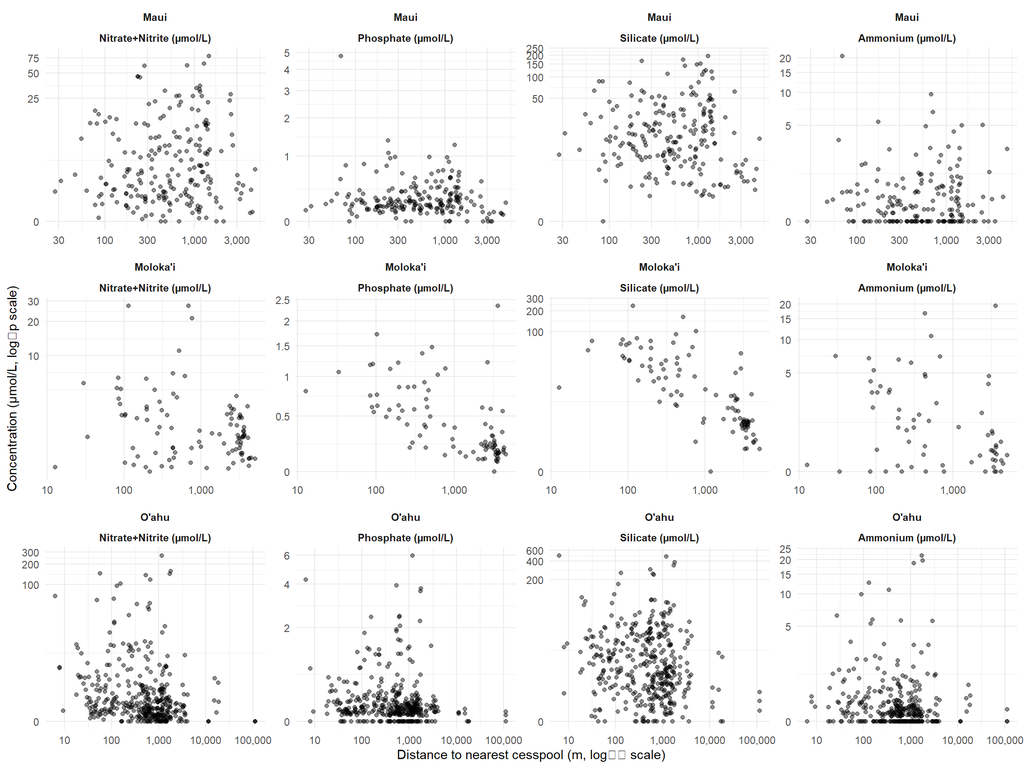

```r
nutrient_labels <- c(
  NO3NO2 = "Nitrate+Nitrite (\u00b5mol/L)",
  PO4    = "Phosphate (\u00b5mol/L)",
  SiO2   = "Silicate (\u00b5mol/L)",
  NH3    = "Ammonium (\u00b5mol/L)"
)

proximity_df <- df_report |>
  filter(
    !is.na(dist_to_nearest_cesspool_m),
    !is.na(island),
    !grepl("L\u0101na", island)
  ) |>
  pivot_longer(c(NO3NO2, PO4, SiO2, NH3),
               names_to  = "nutrient",
               values_to = "concentration") |>
  filter(!is.na(concentration)) |>
  mutate(nutrient = factor(nutrient,
           levels = names(nutrient_labels),
           labels = unname(nutrient_labels)))

ggplot(proximity_df, aes(x = dist_to_nearest_cesspool_m, y = concentration)) +
  geom_point(alpha = 0.45, size = 1.4) +
  scale_x_log10(labels = label_comma()) +
  scale_y_continuous(
    trans  = "log1p",
    labels = label_number(drop0trailing = TRUE)
  ) +
  facet_wrap(island ~ nutrient, scales = "free", ncol = 4) +
  labs(
    x = "Distance to nearest cesspool (m, log\u2081\u2080 scale)",
    y = "Concentration (\u00b5mol/L, log\u2081p scale)"
  ) +
  theme_minimal(base_size = 11) +
  theme(
    strip.text    = element_text(face = "bold"),
    panel.spacing = unit(0.6, "lines")
  )
```

**TipInterpretation**

**Data source:** Cesspool locations from the Hawaiʻi Statewide GIS Program, *Hawaiʻi Cesspool Prioritization Tool (HCPT) Cesspools* (layer 32) and *Onsite Sewage Disposal Systems — Molokaʻi* (layer 23). [geodata.hawaii.gov](https://geodata.hawaii.gov/arcgis/rest/services/Infrastructure/MapServer). Molokaʻi data filtered to Class I (cesspool) systems. Accessed April 28, 2026.

# Mean nutrient concentration by cesspool density

Each dot is one ahupuaʻa, sized by number of water samples. X-axis shows cesspool density (cesspools per km², log scale); y-axis shows mean nutrient concentration (log scale, labeled on normal scale). Error bars show ±1 SE. Only ahupuaʻa with ≥3 analyzed samples shown. Lānaʻi excluded — no cesspool location data are publicly available.

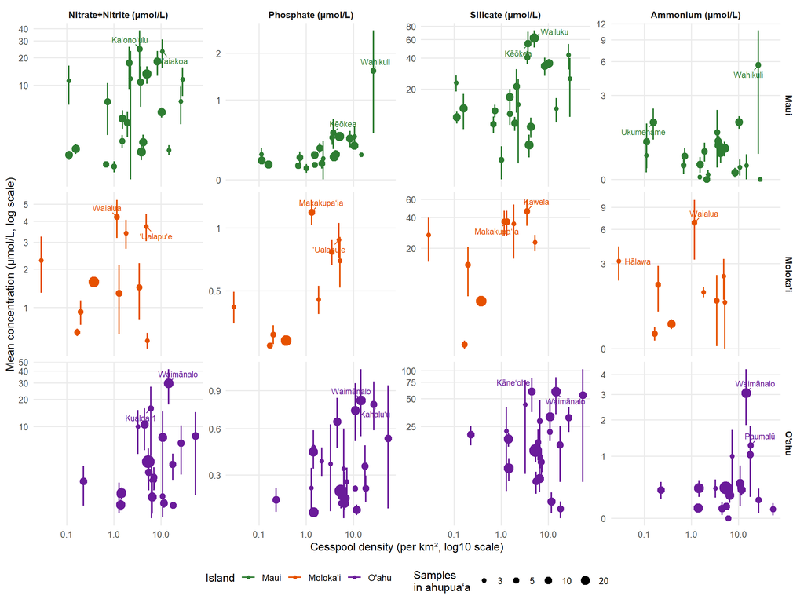

```r
cp_join <- cesspool_by_ahupuaa |>
  mutate(island_key = normalize_island(island)) |>
  select(ahupuaa, island_key, cesspool_density_per_km2)

density_df <- df_chem |>
  filter(!grepl("L\u0101na", island)) |>
  mutate(island_key = normalize_island(island)) |>
  inner_join(cp_join, by = c("ahupuaa", "island_key")) |>
  filter(!is.na(cesspool_density_per_km2)) |>
  pivot_longer(c(NO3NO2, PO4, SiO2, NH3),
               names_to  = "nutrient",
               values_to = "concentration") |>
  filter(!is.na(concentration)) |>
  group_by(ahupuaa, island, cesspool_density_per_km2, nutrient) |>
  summarise(
    mean_conc = mean(concentration),
    se_conc   = sd(concentration) / sqrt(n()),
    n         = n(),
    .groups   = "drop"
  ) |>
  filter(n >= 3) |>
  mutate(nutrient = factor(nutrient,
           levels = names(nutrient_labels),
           labels = unname(nutrient_labels)))

label_df <- density_df |>
  group_by(island, nutrient) |>
  slice_max(mean_conc, n = 2) |>
  ungroup()

ggplot(density_df, aes(x = cesspool_density_per_km2, color = island)) +
  geom_errorbar(
    aes(y = mean_conc, ymin = mean_conc - se_conc, ymax = mean_conc + se_conc),
    width = 0, linewidth = 0.8
  ) +
  geom_point(aes(y = mean_conc, size = n)) +
  geom_text_repel(
    data = label_df,
    aes(y = mean_conc, label = ahupuaa),
    size = 3, show.legend = FALSE,
    min.segment.length = 0.2, box.padding = 0.4, max.overlaps = 20
  ) +
  scale_x_log10(labels = label_comma()) +
  scale_y_continuous(
    trans  = "log1p",
    labels = label_number(drop0trailing = TRUE)
  ) +
  scale_color_manual(values = island_colors, name = "Island") +
  scale_size_continuous(
    name   = "Samples\nin ahupua\u02BBa",
    range  = c(2, 6),
    breaks = c(3, 5, 10, 20)
  ) +
  facet_grid2(island ~ nutrient, scales = "free", independent = "y") +
  labs(
    x = "Cesspool density (per km\u00b2, log10 scale)",
    y = "Mean concentration (\u00b5mol/L, log scale)"
  ) +
  theme_minimal(base_size = 12) +
  theme(
    panel.grid.minor = element_blank(),
    strip.text       = element_text(face = "bold"),
    legend.position  = "bottom"
  )
```

**TipInterpretation**

No strong or consistent relationship is apparent between ahupuaʻa-level cesspool density and mean nutrient concentrations. This likely reflects the influence of other nutrient sources (agricultural runoff, stormwater, stream discharge) that the storm mobilized alongside cesspool leachate, making it difficult to isolate the cesspool signal at this spatial scale with the current sample sizes.

Each dot is one ahupuaʻa, sized by number of water samples. X-axis shows cesspool density (cesspools per km², log scale); y-axis shows mean molar ratio (log scale). DIN = NO₃+NO₂ + NH₃; DIP = PO₄. Error bars show ±1 SE. Only ahupuaʻa with ≥3 valid ratio values shown; samples with a zero-valued denominator (PO₄ = 0 or DIN = 0) are excluded from each ratio’s mean. Lānaʻi excluded — no cesspool location data are publicly available.

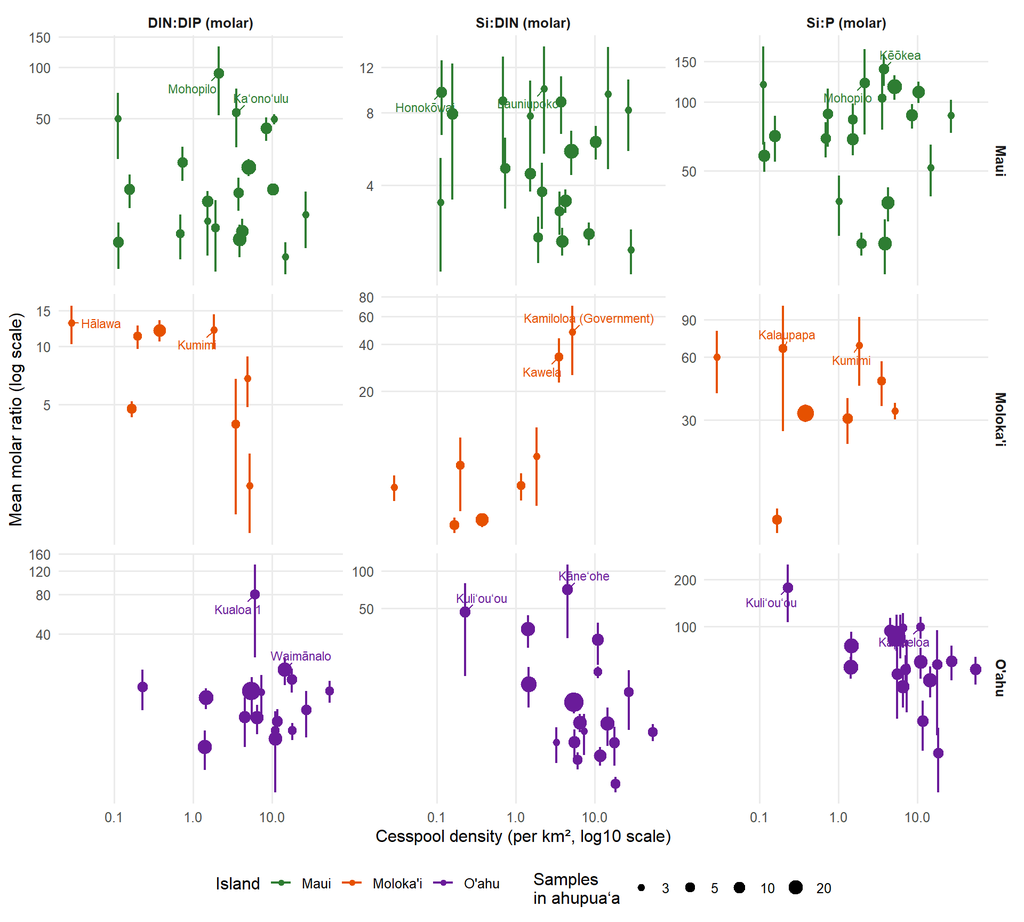

```r
ratio_labels <- c(
  DIN_DIP = "DIN:DIP (molar)",
  Si_DIN  = "Si:DIN (molar)",
  Si_P    = "Si:P (molar)"
)

ratio_df <- df_chem |>
  filter(!grepl("L\u0101na", island)) |>
  mutate(island_key = normalize_island(island)) |>
  inner_join(cp_join, by = c("ahupuaa", "island_key")) |>
  filter(!is.na(cesspool_density_per_km2)) |>
  mutate(
    DIN     = NO3NO2 + NH3,
    DIN_DIP = DIN / PO4,
    Si_DIN  = SiO2 / DIN,
    Si_P    = SiO2 / PO4
  ) |>
  pivot_longer(c(DIN_DIP, Si_DIN, Si_P),
               names_to  = "ratio",
               values_to = "value") |>
  filter(!is.na(value), is.finite(value)) |>
  group_by(ahupuaa, island, cesspool_density_per_km2, ratio) |>
  summarise(
    mean_val = mean(value),
    se_val   = sd(value) / sqrt(n()),
    n        = n(),
    .groups  = "drop"
  ) |>
  filter(n >= 3) |>
  mutate(ratio = factor(ratio,
           levels = names(ratio_labels),
           labels = unname(ratio_labels)))

ratio_label_df <- ratio_df |>
  group_by(island, ratio) |>
  slice_max(mean_val, n = 2) |>
  ungroup()

ggplot(ratio_df, aes(x = cesspool_density_per_km2, color = island)) +
  geom_errorbar(
    aes(y = mean_val, ymin = mean_val - se_val, ymax = mean_val + se_val),
    width = 0, linewidth = 0.8
  ) +
  geom_point(aes(y = mean_val, size = n)) +
  geom_text_repel(
    data = ratio_label_df,
    aes(y = mean_val, label = ahupuaa),
    size = 3, show.legend = FALSE,
    min.segment.length = 0.2, box.padding = 0.4, max.overlaps = 20
  ) +
  scale_x_log10(labels = label_comma()) +
  scale_y_continuous(
    trans  = "log1p",
    labels = label_number(drop0trailing = TRUE)
  ) +
  scale_color_manual(values = island_colors, name = "Island") +
  scale_size_continuous(
    name   = "Samples\nin ahupua\u02BBa",
    range  = c(2, 6),
    breaks = c(3, 5, 10, 20)
  ) +
  facet_grid2(island ~ ratio, scales = "free", independent = "y") +
  labs(
    x = "Cesspool density (per km\u00b2, log10 scale)",
    y = "Mean molar ratio (log scale)"
  ) +
  theme_minimal(base_size = 12) +
  theme(
    panel.grid.minor = element_blank(),
    strip.text       = element_text(face = "bold"),
    legend.position  = "bottom"
  )
```

**TipInterpretation**

**Data source:** Cesspool locations from the Hawaiʻi Statewide GIS Program, *Hawaiʻi Cesspool Prioritization Tool (HCPT) Cesspools* (layer 32) and *Onsite Sewage Disposal Systems — Molokaʻi* (layer 23). [geodata.hawaii.gov](https://geodata.hawaii.gov/arcgis/rest/services/Infrastructure/MapServer). Molokaʻi data filtered to Class I (cesspool) systems. Accessed April 28, 2026.

*Cite these data:* Silbiger, N., Kealoha, A., & Kahanamoku, S. (2026). *What’s In Your Water? — Hawaiʻi Coastal Water Quality Samples, March 2026 Kona Low.* Zenodo. DOI: 10.5281/zenodo.19410137